# Homework 3

Ahmet Pala

16 November 2018

### Task 1.a

There are different types of gesture data in both train and test data. However, this is an acceleration information. In order to visualize them logically, firstly, the information obtained from each gesture instance was converted into the velocity information by taking rowsums of instances. Then the new velocity information was converted into the displacement in three axes. Finally, the instances were plotted in 3 dimensional spaces. As they can be seen from the following figures, instances of 8 gesture types are similar to the gesture shapes given in the Homework 3 sheet.

[interactive chart not shown]

*Figure 1: Instance 1 - Gesture Class 1 from train data*

[interactive chart not shown]

*Figure 2: Instance 2 - Gesture Class 2 from train data*

[interactive chart not shown]

*Figure 3: Instance 3 - Gesture Class 3 from train data*

[interactive chart not shown]

*Figure 4: Instance 4 - Gesture Class 4 from train data*

[interactive chart not shown]

*Figure 5: Instance 5 - Gesture Class 5 from train data*

[interactive chart not shown]

*Figure 6: Instance 6 - Gesture Class 6 from train data*

[interactive chart not shown]

*Figure 7: Instance 7 - Gesture Class 7 from train data*

[interactive chart not shown]

*Figure 8: Instance 8 - Gesture Class 8 from train data*

### Task 1.b

In this task, the information of X, Y and Z were cobined in a particular dataset and a single vector was obtained for each data so that we can apply nearest-neighbor (NN) classifier. In order to obtain more accurate results, the data was normalized. After preparing the data to nearest-neighbor algorithm, 10-fold cross validation was used in order to obtaining the more accurate k value. The procedure was applied with the “caret” package for the Euclidean distance (since it is the default distance measure and it cannot be changed). All the procedure can be seen from the R codes given in the Appendix.

#### Euclidean Distance

```
## k-Nearest Neighbors
##
## 896 samples
## 945 predictors
##   8 classes: '1', '2', '3', '4', '5', '6', '7', '8'
##
## No pre-processing
## Resampling: Cross-Validated (10 fold)
## Summary of sample sizes: 806, 807, 807, 806, 807, 808, ...
## Resampling results across tuning parameters:
##
##   k  Accuracy   Kappa
##   1  0.9430312  0.9348139
##   2  0.9284364  0.9181038
##   3  0.9452792  0.9373748
##   4  0.9385987  0.9297284
##   5  0.9351901  0.9258261
##
## Accuracy was used to select the optimal model using the largest value.
## The final value used for the model was k = 3.
```

*Figure 9: Accuracies based on different k values*

As can be seen from the figure, the optimum k value for the Euclidean distance measure is 3 with the accuracy of 0.95.

#### Manhattan Distance

```
## [1] 855 838 851 850 847 847 846
```

*Figure 11: Number of accurate predictions for k values 1,2,3,4,5,6,7 respectively*

After implementing the code, it can be seen that the maximum accurate predictions are observed for the k value 1 (855 true predictions). However, using the k value as 1 may lead to some problems such as the sensitivity for the outliers. Moreover, if we try the model several times and change the randomness parameter, we may obtain different, more logical k values. Therefore, for this particular case, optimum k value was preferred as 3 since the closer k point to the 1 in terms of the accurate predictions is 3 (851 true predictions).

### Task 1.c

#### Euclidean Distance

After determining the k value as 3 for Euclidean distance measure, the knn procedure was applied to the combined data (test and train together) for determining the accuracy. By the way, normalization was applied here again so that the more accurate results can be obtained.

```
##
## pred_1   1   2   3   4   5   6   7   8
##      1 431   1   2   2   3   8   0   0
##      2   0 449   0   0   0   0   0   0
##      3   0   0 410   0   5   7   4   0
##      4   2   0   0 374   1  16   0   2
##      5   0   0  15  57 423  29   0   0
##      6   4   0  22  10   1 389   0   0
##      7   0   2   5   0   0   0 443   0
##      8   0   0   0   7   0   0   0 458
```

```
## [1] 0.9454088
```

*Figure 12: Confusion Matrix and the accuracy for Euclidean distance measure for k=3*

As can be seen from the figure, most of the data was labeled correctly. The accuracy is 94.54 % and the run time relatively long compared to manhattan distance.

#### Manhattan Distance

After implementing the code, the confusion matrix and the accuracy can be seen from the figure below.

```
##        1   2   3   4   5   6   7   8
## [1,] 432   0   0   2   0   3   0   0
## [2,]   1 451   0   0   0   0   0   0
## [3,]   3   0 420   0  11  16   4   0
## [4,]   3   0   0 385  48   7   0   7
## [5,]   3   0   5   2 422   1   0   0
## [6,]  10   0   4  16  25 394   0   0
## [7,]   0   0   5   0   0   0 442   0
## [8,]   0   0   0   2   1   0   0 457
```

```
##         1
## 0.9501757
```

*Figure 14: Confusion matrix and the accuracy for Manhattan distance*

As can be seen from the figure, a big portion of the data was predicted as true. Note that the accuracy is 95.01% and the run time is shorter compared to the Euclidean distance measure.

### Task 2.a

In this task, the main aim is to apply logistic regression with fused lasso penalties. In this regression procedure, determining the lambda values is of interest first. in order to overcome this issue, cross validation was applied to the dataset. (Note that the labels was -1 or 1. In order to apply logistic regression we need to have the labels 1 and zero, and the data was prepared before the procedures). After determining the parameters, the prediction model was created and used on test data. Cross validation procedure, the accuracy of the model (on the test data) and the confusion matrix can be observed the figure below. The penalized package was used for fusel lasso regression procedures.

```
## lambda= 6.145676     123cvl= -44.8649
## lambda= 9.943912     123cvl= -53.93867
## lambda= 3.798236     123cvl= -37.74883
## lambda= 2.347439     123cvl= -34.54965
## lambda= 1.450797     123cvl= -34.30892
## lambda= 1.736403     123cvl= -33.9455
## lambda= 1.845887     123cvl= -33.94292
## lambda= 1.794872     123cvl= -33.93882
## lambda= 1.797772     123cvl= -33.93872
## lambda= 1.803517     123cvl= -33.93864
## lambda= 1.803394     123cvl= -33.93864
## lambda= 1.800645     123cvl= -33.93866
## lambda= 1.802344     123cvl= -33.93864
## lambda= 1.802931     123cvl= -33.93864
## lambda= 1.803224     123cvl= -33.93864
```

```
## lambda= Inf  cvl= -62.11058
## lambda= 1    123cvl= -33.22776
## lambda= 10   123cvl= -41.37475
## lambda= 0.1  123cvl= -32.28348
## lambda= 0.01     123cvl= -33.06125
## lambda= 0.3881464    123cvl= -32.54242
## lambda= 0.6218536    123cvl= -32.78513
## lambda= 0.2437073    123cvl= -32.38315
## lambda= 0.1544391    123cvl= -32.25619
## lambda= 0.09926824   123cvl= -32.29873
## lambda= 0.1522453    123cvl= -32.25234
## lambda= 0.1349541    123cvl= -32.20186
## lambda= 0.1213233    123cvl= -32.11737
## lambda= 0.112899     123cvl= -32.12254
## lambda= 0.1181039    123cvl= -32.11666
## lambda= 0.1190218    123cvl= -32.11539
## lambda= 0.1195543    123cvl= -32.11547
## lambda= 0.119213     123cvl= -32.11513
## lambda= 0.1192702    123cvl= -32.11517
## lambda= 0.1191957    123cvl= -32.11515
## lambda= 0.1192278    123cvl= -32.11513
```

```
## [1] 0.83
```

```
##
##      0  1
##   0 25 11
##   1  6 58
```

*Figure 15: Cross validation procedure, the accuracy of the model and the confusion matrix*

As can be seen from the figure, the accuracy of the model is 83 %. This means that the prediction model works well to predict the labels (binary labels) in the test data. The confusion matrix also can be seen from the figure.

### Task 2.b

The regression coefficients can be obtained by the specific command of the penalized package “coefficients”. The coefficients are printed in the figure below. Then, for visualization, the coefficients were plotted also in the figure 17.

```
## (Intercept)
##  0.50742601 -0.13767358  0.00000000  0.00000000  0.00000000  0.00000000
##
## -0.18082666 -0.37818713  0.00000000  0.00000000  0.00000000  0.00000000
##
##  1.04745399  0.00000000  0.00000000  0.00000000  0.00000000  0.00000000
##
##  0.00000000  0.00000000  0.00000000  0.00000000  0.00000000  0.00000000
##
##  0.00000000  0.00000000  0.00000000  0.00000000  0.00000000  0.00000000
##
## -0.34720324 -0.34720324  0.00000000  0.00000000 -0.18224153 -0.18224153
##
##  0.00000000  0.00000000  0.00000000  0.00000000  0.00000000  0.00000000
##
##  0.00000000  0.00000000  0.48361422  0.48361422  0.00000000  0.00000000
##
##  0.00000000  0.00000000  0.00000000  0.00000000  0.00000000  0.00000000
##
##  0.00000000  0.00000000  0.00000000  0.00000000  0.00000000  0.00000000
##
##  0.00000000  0.00000000  0.00000000  0.00000000  0.00000000  0.00000000
##
##  0.00000000  0.00000000  0.00000000  0.00000000  0.00000000  0.00000000
##
##  0.00000000  0.00000000  0.00000000  0.00000000  0.00000000  0.00000000
##
##  0.00000000  0.00000000  0.00000000 -0.07876312 -0.07876312  0.00000000
##
##  0.00000000  0.00000000  0.00000000  0.00000000  0.00000000  0.00000000
##
##  0.00000000  0.00000000  0.00000000  0.00000000  0.00000000 -0.62173668
##
## -0.95740853
```

*Figure 16: The regression coefficients*

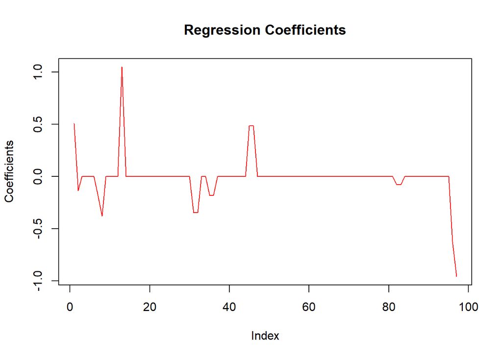

*Figure 17: The regression coefficients*

As can be from the figure 16 and figure 17, some coefficients of the features take the value zero (0), which means that some of the features are not important for this regression models. Some of the coefficients take positive values while the others take negative values, these variables are so called latent variables. We can interpret the importance of the features by the absolute values of the coefficients.

### Task 2.c

In this task, the logistic regression with fused lasso penalties was implemented after the data manupulation. Recall that the original data was in the form of time series. The difference between consecutive time series observations were taken to transform the time series. Let xt be the observation at time point t and the new time series were created which yt=xt-(xt-1) for t=2,3,…,T where T is the length of the time series. After preparing the data, the same procedure in part a was implemented to the new dataset. Cross validation procedure, the accuracy of the model (on the test data) and the confusion matrix can be observed the figure below. The penalized package was again used for fusel lasso regression procedures.

```
## lambda= 4.508664     123cvl= -47.43488
## lambda= 7.295172     123cvl= -55.8505
## lambda= 2.786508     123cvl= -40.00586
## lambda= 1.722157     123cvl= -32.79543
## lambda= 1.064351     123cvl= -29.85628
## lambda= 0.6578053    123cvl= -29.7592
## lambda= 0.8310302    123cvl= -29.66289
## lambda= 0.8260277    123cvl= -29.6562
## lambda= 0.7691242    123cvl= -29.61665
## lambda= 0.7266041    123cvl= -29.64072
## lambda= 0.7701767    123cvl= -29.61659
## lambda= 0.7722835    123cvl= -29.61656
## lambda= 0.792812     123cvl= -29.62295
## lambda= 0.7717221    123cvl= -29.61655
## lambda= 0.7717234    123cvl= -29.61655
## lambda= 0.7711318    123cvl= -29.61656
## lambda= 0.7714966    123cvl= -29.61655
## lambda= 0.77161  123cvl= -29.61655
```

```
## lambda= Inf  cvl= -62.11058
## lambda= 1    123cvl= -33.81806
## lambda= 10   123cvl= -43.36806
## lambda= 0.1  123cvl= -30.24088
## lambda= 0.01     123cvl= -29.74671
## lambda= 0.001    123cvl= -29.62932
## lambda= 1e-04    123cvl= -29.61782
## lambda= 1e-05    123cvl= -29.61668
## lambda= 1e-06    123cvl= -29.61656
## lambda= 1e-07    123cvl= -29.61655
## lambda= 1e-08    123cvl= -29.61655
## lambda= 1e-09    123cvl= -29.61655
## lambda= 1e-10    123cvl= -29.61655
## lambda= 3.881464e-09     123cvl= -29.61655
## lambda= 6.218536e-09     123cvl= -29.61655
## lambda= 2.437073e-09     123cvl= -29.61655
## lambda= 4.630628e-09     123cvl= -29.61655
## lambda= 3.329755e-09     123cvl= -29.61655
## lambda= 4.167619e-09     123cvl= -29.61655
## lambda= 3.67073e-09  123cvl= -29.61655
## lambda= 3.990765e-09     123cvl= -29.61655
## lambda= 3.80097e-09  123cvl= -29.61655
```

```
## [1] 0.84
```

```
##
##      0  1
##   0 28  8
##   1  8 56
```

*Figure 18: Cross validation procedure, the accuracy of the model and the confusion matrix* As can be seen from the figure, the accuracy for the new dataset was increased from 83 % to 84 % (according the part a).

### Task 2.d

After implementing the model, the new regression coefficients were observed for the new dataset. The new coefficients can seen from the figure 19. The new regression coefficients also plotted, and it can be seen from the figure 20.

```
## (Intercept)
##  0.48724109  0.00000000  0.00000000  0.89705410  0.13699300  0.00000000
##
## -1.85658882  0.00000000 -0.71752686  0.00000000  0.00000000  0.00000000
##
##  2.40247061  0.00000000  0.00000000  0.00000000  0.00000000  0.00000000
##
##  0.00000000  0.00000000  0.00000000  0.00000000  0.00000000  0.00000000
##
##  0.00000000  0.00000000  0.00000000  0.00000000  0.00000000 -1.65759935
##
##  0.00000000  0.00000000  0.00000000  0.00000000  0.00000000 -1.00312727
##
##  0.00000000  0.00000000  0.00000000  0.00000000  0.00000000  0.00000000
##
##  0.00000000  0.00000000  1.37184006  0.00000000  0.00000000  0.00000000
##
##  0.00000000  0.00000000  0.00000000  0.00000000  0.00000000  0.00000000
##
##  0.00000000  0.00000000  0.00000000  0.00000000  0.00000000  0.00000000
##
##  0.00000000  0.00000000  0.00000000  0.00000000  0.00000000  0.00000000
##
##  0.00000000  0.00000000  0.00000000  0.00000000  0.00000000  0.00000000
##
##  0.00000000  0.00000000  0.24465146  0.00000000  0.00000000  0.00000000
##
##  0.00000000  0.00000000 -0.17060444  0.00000000  0.00000000  0.00000000
##
## -0.21102387  0.00000000  0.00000000  0.00000000  0.00000000  0.00000000
##
## -0.69599997  0.00000000  0.00000000  0.00000000 -0.00885022 -1.49711905
##
##  0.00000000
```

*Figure 19: The new Regression coefficients*

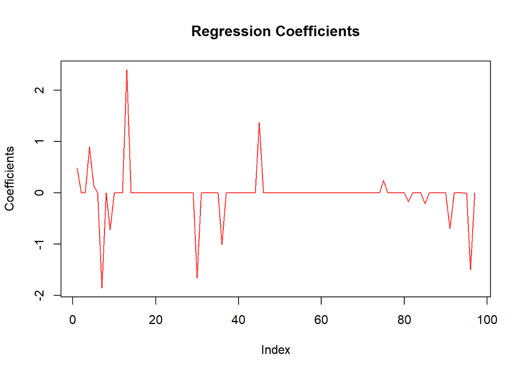

*Figure 20: The new Regression coefficients*